# Phase 2

Jay Gohner

November 21, 2019

My idea for this phase was to see if an increase in adults obtaining higher levels of education had any effect on rates of violent crime.

After gathering and cleaning data for adults rates of education from 1970 to 2000, we know focus on gathering data on rates of violent crime for those same years. First we will pull in all our data from our previous project to use for this step of the project.

```r
suppressMessages(library("tidyverse"))
suppressMessages(library("knitr"))
suppressMessages(library("caret"))
purl("deliverable1.rmd", output = "part1.r")
```

```
##
##
## processing file: deliverable1.rmd
```

[output not shown]

```
## output file: part1.r
```

```
## [1] "part1.r"
```

```r
source("part1.r")
```

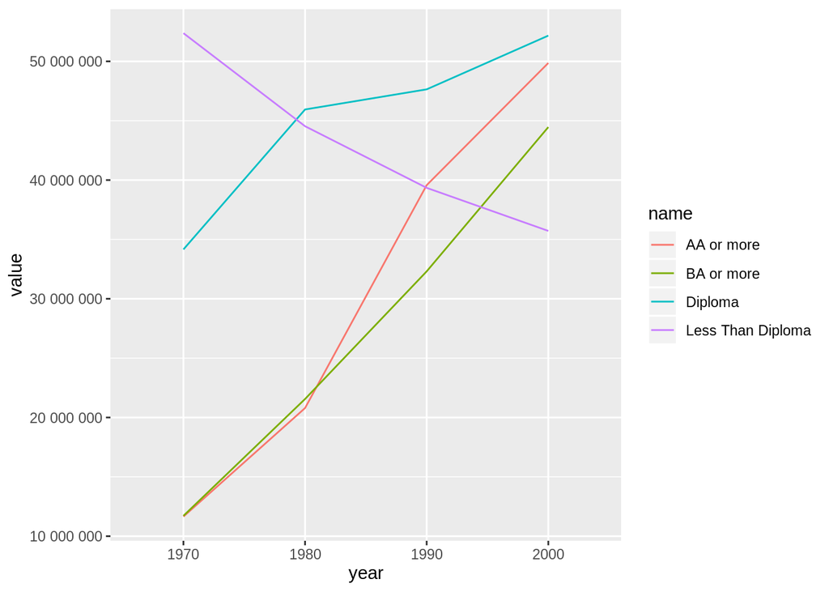

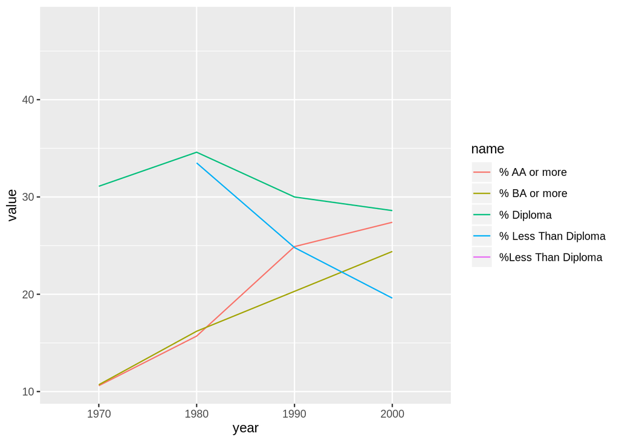

I found a large xlsx from https://www.ucrdatatool.gov/Search/Crime/State/RunCrimeStatebyState.cfm This dataset contains the population of the state and the number of incidents of violent crime which are classified as: Violent Crime Total Murder and Manslaughter Legacy Rape Revised Rape (the empty category) Robbery Aggravated Assault The dataset was actually quite clean for the most part. I needed to remove the Revised rape column as it had been depracated and was no longer in use. I changed up a few of the column names to make them easier to read and work with.

```r
Crime_US <- read_excel("crimeAllStates.xlsx", skip=9)
colnames(Crime_US)[colnames(Crime_US) == "Revised rape /2"] <- "delete"
Crime_US <- subset(Crime_US, select = -c(delete))
colnames(Crime_US)[colnames(Crime_US) == "Legacy rape /1"] <- "Rape"
colnames(Crime_US)[colnames(Crime_US) == "Violent crime total"] <- "Violent_crime_total"
colnames(Crime_US)[colnames(Crime_US) == "Murder and nonnegligent Manslaughter"] <- "Murder_and_Manslaughter"
colnames(Crime_US)[colnames(Crime_US) == "Aggravated assault"] <- "Aggravated_assault"
```

The challenging part was splitting the large dataset up by state so that I could have state based models. I first created a vector of States names. The next step was to create an empty list which I will then fill in a loop. I know that each tibble for the state will be 31 rows long so I set tracking variables m and n to make sure I get exactly the rows I need for each tibble. The for loop goes the length of the state names vector and each time it makes a tibble from Crime_US using slice and then mutate to add a name column. After the for loop I use the names function to name every element in the list after an element in my state names vector. The function list2env then turns a list of tibbles into the global environment.

```r
states_vec <- c("Alabama", "Alaska", "Arizona", "Arkansas", "California", "Colorado", "Connecticut", "Delaware", "D.C.", "Florida", "Georgia", "Hawaii", "Idaho", "Illinois", "Indiana", "Iowa", "Kansas", "Kentucky", "Louisiana", "Maine", "Maryland", "Massachusetts", "Michigan", "Minnesota", "Mississippi", "Missouri", "Montana", "Nebraska", "Nevada", "New Hampshire", "New Jersey", "New Mexico", "New York", "North Carolina", "North Dakota", "Ohio", "Oklahoma", "Oregon", "Pennslyvania", "Rhode Island", "South Carolina", "South Dakota", "Tennessee", "Texas", "Utah", "Vermont", "Virginia", "Washington", "West Virginia", "Wisconsin", "Wyoming")

state_crime <- list()
m <- 1
n <- 31

for (i in 1:length(states_vec)){

  state_crime[[i]] <- slice(Crime_US, m:n) %>%
                        mutate(state = states_vec[i])
  m <- (m + 39)
  n <- (n + 39)
}

names(state_crime) <- states_vec

bind_rows(state_crime)
```

```
## # A tibble: 1,581 x 8
##    Year  Population Violent_crime_t… Murder_and_Mans… Rape  Robbery
##    <chr> <chr>      <chr>            <chr>            <chr> <chr>
##  1 1970  3444165    10185            404              637   1731
##  2 1971  3479000    10835            524              661   2005
##  3 1972  3510000    10994            496              660   2407
##  4 1973  3539000    12390            468              751   2809
##  5 1974  3577000    13338            536              811   3562
##  6 1975  3614000    14201            577              738   4446
##  7 1976  3665000    14248            553              794   3520
##  8 1977  3690000    15293            524              929   3572
##  9 1978  3742000    15682            499              954   3708
## 10 1979  3769000    15578            496              1037  4127
## # … with 1,571 more rows, and 2 more variables: Aggravated_assault <chr>,
## #   state <chr>
```

```r
list2env(state_crime, .GlobalEnv)
```

```
## <environment: R_GlobalEnv>
```

I then realized I had to further break down the dataframes with state info into smaller dataframes with just the years for 1970 1980 1990 and 2000, becuase those were the only years I had my education data for. As I made the state tibbles for violent crime I would then use the left_join function to combine the education tibble with the appropriate crime tibble. The final tables that can be used for modelling are labeled as state abbreviations that have been capitalized.

```r
al_decades <- filter(Alabama, Year %in% c(1970, 1980, 1990, 2000))
AL <- left_join(alabama_ed_decades, al_decades, by = c("area_name"="state"))

ak_decades <- filter(Alaska, Year %in% c(1970, 1980, 1990, 2000))
AK <- left_join(alaska_ed_decades, ak_decades, by = c("area_name"="state"))

az_decades <- filter(Arizona, Year %in% c(1970, 1980, 1990, 2000))
AZ <- left_join(arizona_ed_decades, az_decades, by = c("area_name"="state"))

as_decades <- filter(Arkansas, Year %in% c(1970, 1980, 1990, 2000))
AS <- left_join(arkansas_ed_decades, as_decades, by = c("area_name"="state"))

ca_decades <- filter(California, Year %in% c(1970, 1980, 1990, 2000))
CA <- left_join(california_ed_decades, ca_decades, by = c("area_name"="state"))

co_decades <- filter(Colorado, Year %in% c(1970, 1980, 1990, 2000))
CO <- left_join(colorado_ed_decades, co_decades, by = c("area_name"="state"))

de_decades <- filter(Delaware, Year %in% c(1970, 1980, 1990, 2000))
DE <- left_join(delaware_ed_decades, de_decades, by = c("area_name"="state"))

dc_decades <- filter(D.C., Year %in% c(1970, 1980, 1990, 2000))
DC <- left_join(dc_ed_decades, dc_decades, by = c("area_name"="state"))

fl_decades <- filter(Florida, Year %in% c(1970, 1980, 1990, 2000))
FL <- left_join(florida_ed_decades, fl_decades, by = c("area_name"="state"))

ga_decades <- filter(Georgia, Year %in% c(1970, 1980, 1990, 2000))
GA <- left_join(georgia_ed_decades, ga_decades, by = c("area_name"="state"))

ha_decades <- filter(Hawaii, Year %in% c(1970, 1980, 1990, 2000))
HA <- left_join(hawaii_ed_decades, ha_decades, by = c("area_name"="state"))

id_decades <- filter(Idaho, Year %in% c(1970, 1980, 1990, 2000))
ID <- left_join(idaho_ed_decades, id_decades, by = c("area_name"="state"))

il_decades <- filter(Illinois, Year %in% c(1970, 1980, 1990, 2000))
IL <- left_join(illinois_ed_decades, il_decades, by = c("area_name"="state"))

in_decades <- filter(Indiana, Year %in% c(1970, 1980, 1990, 2000))
IN <- left_join(indiana_ed_decades, in_decades, by = c("area_name"="state"))

iw_decades <- filter(Iowa, Year %in% c(1970, 1980, 1990, 2000))
IW <- left_join(iowa_ed_decades, iw_decades, by = c("area_name"="state"))

ks_decades <- filter(Kansas, Year %in% c(1970, 1980, 1990, 2000))
KS <- left_join(kansas_ed_decades, ks_decades, by = c("area_name"="state"))

ky_decades <- filter(Kentucky, Year %in% c(1970, 1980, 1990, 2000))
KY <- left_join(kentucky_ed_decades, ky_decades, by = c("area_name"="state"))

ls_decades <- filter(Louisiana, Year %in% c(1970, 1980, 1990, 2000))
LS <- left_join(louisiana_ed_decades, ls_decades, by = c("area_name"="state"))

ma_decades <- filter(Maine, Year %in% c(1970, 1980, 1990, 2000))
ME <- left_join(maine_ed_decades, ma_decades, by = c("area_name"="state"))

md_decades <- filter(Maryland, Year %in% c(1970, 1980, 1990, 2000))
MA <- left_join(maryland_ed_decades, md_decades, by = c("area_name"="state"))

mt_decades <- filter(Massachusetts, Year %in% c(1970, 1980, 1990, 2000))
MT <- left_join(mass_ed_decades, mt_decades, by = c("area_name"="state"))

mc_decades <- filter(Michigan, Year %in% c(1970, 1980, 1990, 2000))
MC <- left_join(michigan_ed_decades, mc_decades, by = c("area_name"="state"))

mn_decades <- filter(Minnesota, Year %in% c(1970, 1980, 1990, 2000))
MN <- left_join(minnesota_ed_decades, mn_decades, by = c("area_name"="state"))

ms_decades <- filter(Mississippi, Year %in% c(1970, 1980, 1990, 2000))
MS <- left_join(mississippi_ed_decades, ms_decades, by = c("area_name"="state"))

mo_decades <- filter(Missouri, Year %in% c(1970, 1980, 1990, 2000))
MO <- left_join(missouri_ed_decades, mo_decades, by = c("area_name"="state"))

mon_decades <- filter(Montana, Year %in% c(1970, 1980, 1990, 2000))
MON <- left_join(montana_ed_decades, mon_decades, by = c("area_name"="state"))

ne_decades <- filter(Nebraska, Year %in% c(1970, 1980, 1990, 2000))
NE <- left_join(nebraska_ed_decades, ne_decades, by = c("area_name"="state"))

nv_decades <- filter(Nevada, Year %in% c(1970, 1980, 1990, 2000))
NV <- left_join(nevada_ed_decades, nv_decades, by = c("area_name"="state"))

nh_decades<- filter(`New Hampshire`, Year %in% c(1970, 1980, 1990, 2000))
NH <- left_join(newHampshire_ed_decades, nh_decades, by = c("area_name"="state"))

nj_decades <- filter(`New Jersey`, Year %in% c(1970, 1980, 1990, 2000))
NJ <- left_join(newJersey_ed_decades, nj_decades, by = c("area_name"="state"))

nm_decades <- filter(`New Mexico`, Year %in% c(1970, 1980, 1990, 2000))
NM <- left_join(newMexico_ed_decades, nm_decades, by = c("area_name"="state"))

ny_decades <- filter(`New York`, Year %in% c(1970, 1980, 1990, 2000))
NY <- left_join(newYork_ed_decades, ny_decades, by = c("area_name"="state"))

nc_decades <- filter(`North Carolina`, Year %in% c(1970, 1980, 1990, 2000))
NC <- left_join(northCarolina_ed_decades, nc_decades, by = c("area_name"="state"))

nd_decades <- filter(`North Dakota`, Year %in% c(1970, 1980, 1990, 2000))
ND <- left_join(northDakota_ed_decades, nd_decades, by = c("area_name"="state"))

oh_decades <- filter(Ohio, Year %in% c(1970, 1980, 1990, 2000))
OH <- left_join(ohio_ed_decades, oh_decades, by = c("area_name"="state"))

ok_decades <- filter(Oklahoma, Year %in% c(1970, 1980, 1990, 2000))
OK <- left_join(oklahoma_ed_decades, ok_decades, by = c("area_name"="state"))

or_decades <- filter(Oregon, Year %in% c(1970, 1980, 1990, 2000))
OR <- left_join(oregon_ed_decades, or_decades, by = c("area_name"="state"))

pn_decades <- filter(Pennslyvania, Year %in% c(1970, 1980, 1990, 2000))
PN <- left_join(pennslyvania_ed_decades, pn_decades, by = c("area_name"="state"))

ri_decades <- filter(`Rhode Island`, Year %in% c(1970, 1980, 1990, 2000))
RI <- left_join(rhodeIsland_ed_decades, ri_decades, by = c("area_name"="state"))

sc_decades <- filter(`South Carolina`, Year %in% c(1970, 1980, 1990, 2000))
SC <- left_join(southCarolina_ed_decades, sc_decades, by = c("area_name"="state"))

sd_decades <- filter(`South Dakota`, Year %in% c(1970, 1980, 1990, 2000))
SD <- left_join(southDakota_ed_decades, sd_decades, by = c("area_name"="state"))

tn_decades <- filter(Tennessee, Year %in% c(1970, 1980, 1990, 2000))
TN <- left_join(tennessee_ed_decades, tn_decades, by = c("area_name"="state"))

tx_decades <- filter(Texas, Year %in% c(1970, 1980, 1990, 2000))
TX <- left_join(texas_ed_decades, tx_decades, by = c("area_name"="state"))

ut_decades <- filter(Utah, Year %in% c(1970, 1980, 1990, 2000))
UT <- left_join(utah_ed_decades, ut_decades, by = c("area_name"="state"))

vt_decades <- filter(Vermont, Year %in% c(1970, 1980, 1990, 2000))
VT <- left_join(vermont_ed_decades, vt_decades, by = c("area_name"="state"))

va_decades <- filter(Virginia, Year %in% c(1970, 1980, 1990, 2000))
VA <- left_join(virginia_ed_decades, va_decades, by = c("area_name"="state"))

wa_decades <- filter(Washington, Year %in% c(1970, 1980, 1990, 2000))
WA <- left_join(washington_ed_decades, wa_decades, by = c("area_name"="state"))

wv_decades <- filter(`West Virginia`, Year %in% c(1970, 1980, 1990, 2000))
WV <- left_join(westVirginia_ed_decades, wv_decades, by = c("area_name"="state"))

wi_decades <- filter(Wisconsin, Year %in% c(1970, 1980, 1990, 2000))
WI <- left_join(wisconsin_ed_decades, wi_decades, by = c("area_name"="state"))

wy_decades <- filter(Wyoming, Year %in% c(1970, 1980, 1990, 2000))
WY <- left_join(wyoming_ed_decades, wy_decades, by = c("area_name"="state"))
```

We have nearly 50 tables with which to make a model. I decided to start with our home state. To make a valid model we will need a per capita column of both diploma and violent crime total.

```r
CA[, "Diploma_per_cap"] <-  (as.numeric(unlist(CA[,"Diploma"])) / as.numeric(unlist(CA[,"Population"])))
CA[, "Violence_per_cap"] <-  (as.numeric(unlist(CA[,"Violent_crime_total"])) / as.numeric(unlist(CA[,"Population"])))

corr_set <-lm(data=CA, formula=Violence_per_cap~Diploma_per_cap)

summary(corr_set)
```

```
##
## Call:
## lm(formula = Violence_per_cap ~ Diploma_per_cap, data = CA)
##
## Residuals:
##        Min         1Q     Median         3Q        Max
## -0.0026980 -0.0021133 -0.0001055  0.0019226  0.0025823
##
## Coefficients:
##                  Estimate Std. Error t value Pr(>|t|)
## (Intercept)      0.011465   0.002564   4.471 0.000528 ***
## Diploma_per_cap -0.024230   0.015650  -1.548 0.143871
## ---
## Signif. codes:  0 '***' 0.001 '**' 0.01 '*' 0.05 '.' 0.1 ' ' 1
##
## Residual standard error: 0.002207 on 14 degrees of freedom
## Multiple R-squared:  0.1462, Adjusted R-squared:  0.0852
## F-statistic: 2.397 on 1 and 14 DF,  p-value: 0.1439
```

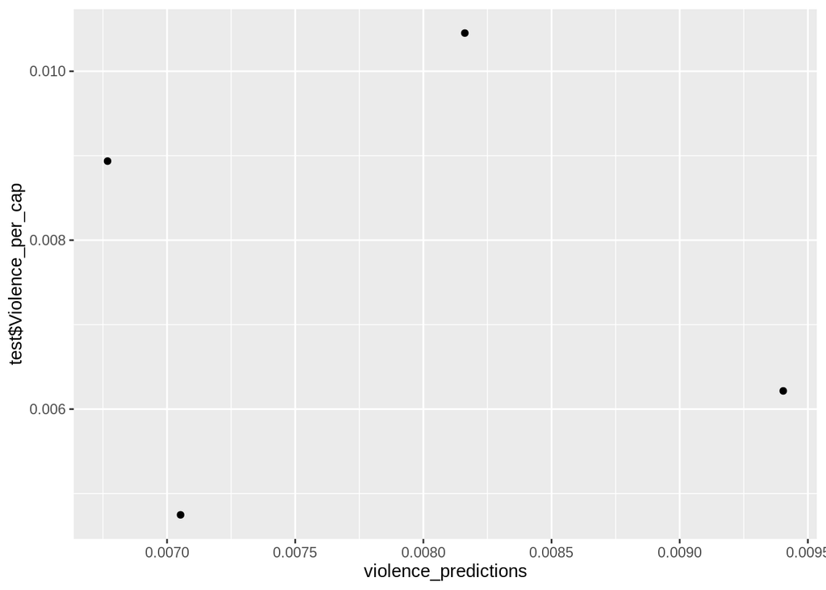

```r
sampling = createDataPartition(CA$Violence_per_cap, p = 0.70, list = FALSE) # p to tell 70% split
train = CA[sampling, ]
test = CA[-sampling, ]
predict_violence_model <- lm(data=train, formula = Violence_per_cap ~ Diploma_per_cap)
violence_predictions <- predict(predict_violence_model, test)
ggplot(data=test, aes(x=violence_predictions, y=test$Violence_per_cap)) + geom_point()
```

```r
R2(violence_predictions,test$Violence_per_cap)
```

```
## [1] 0.002187022
```

```r
MAE(violence_predictions,test$Violence_per_cap)
```

```
## [1] 0.002487797
```

```r
RMSE(violence_predictions,test$Violence_per_cap)
```

```
## [1] 0.002521016
```

As we can see our in our summary our pvalue was too high for my model to be statistically significant. Also when testing my model I found the R2, MAE and RMSE values to be below one which tells me the predictive model doesn’t even match my data. Below is an attempt at a graph to show the results of my predictive model.

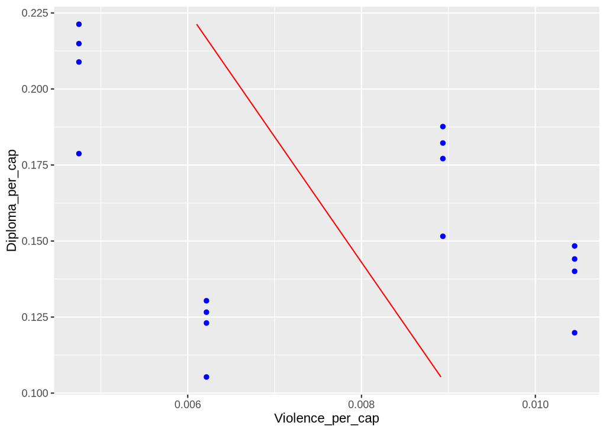

```r
prediction <-data.frame(crime_predict = predict(corr_set, CA), diploma=CA$Diploma_per_cap)

ggplot(data=CA, aes(x=Violence_per_cap, y=Diploma_per_cap)) + geom_point(color='blue') + geom_line(color='red', data = prediction, aes(x=crime_predict, y=diploma))
```